# Investigating Bus Suspects: A Journey Through Delays & Crowds

## Lets set the stage: What’s our Problem?

Every day, many of us rely on public transport and experience varying trip lengths, delays, and crowds. But what causes these problems? Why do they emerge? When we log and analyze this information systematically are we able to find out patterns that may help us in the future? Using a dataset of bus trip logs, let’s explore how time of day, day of the week, and trip characteristics impact the rider experience. Please be seated or holding the rail bars at all times!

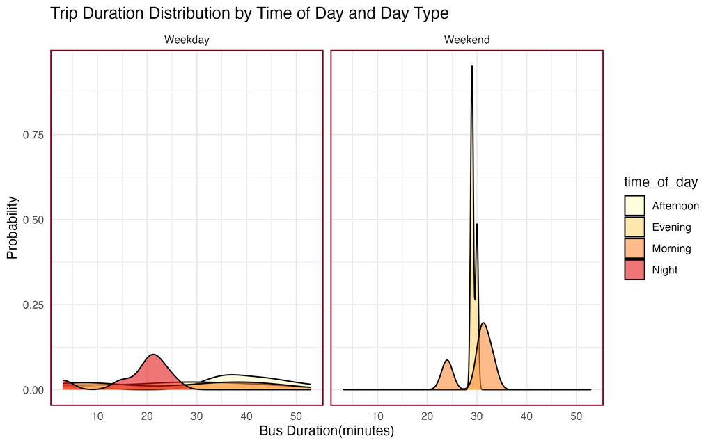

We can start to examine how trip durations vary depending on the time of day and whether it’s a weekday or weekend. The density plot above reveals noticeable differences in bus trip lengths throughout the day.

We can see that there is a lot more variability in bus trip duration during weekdays compared to weekends. When we look at the weekday side first, the only time of day that is not so variable is the **Night**. We can see that there is pretty high probability that bus duration will be around 20 minutes, which is much lower compared to buses taken during the morning, afternoon and evening. This is most likely due to the fact that buses are much less crowded during the night, and peak hours are during the morning and afternoon period(for university students, for full-time working adults, the evening more of a rush hour than the afternoon).

I think these results can help me identify what the best times are to take public transport when I have a choice. In my case, it seems that night buses result in the shortest bus durations, so I could potentially wait/study at Uni until night to avoid traffic or delays when possible.

## Quantifying Delay With An Intelligent Twist?

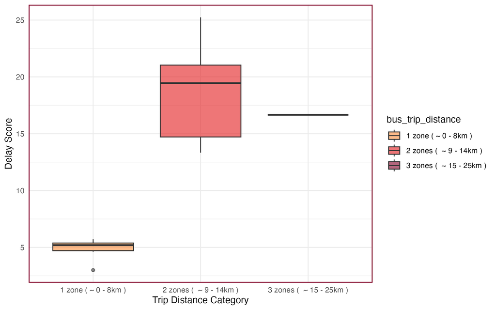

This is a similar relationship to our density plot, but here we have tried to calculate a way to normalise delay. So I kind of pulled this concept from CS110 when we learnt about artificial neurons. To make the comparison fair, I made my own metric: *delay_score = bus_duration / (distance_factor x crowdedness_factor)*.

The idea was to account for trip complexity, as longer trips should naturally take longer, and crowded buses should move more slowly. This isn’t an official formula, but more of a prototype inspired by how weights are handled in artificial neurons (thanks, CS110!).

Now lets get on with the results from the plot. As we can see, 2 zones has by far the highest delay score, in comparison to 1 zone and 3 zones. Which is to be expected, as longer journeys essentially are more likely to introduce some random event that may cause delay. I dont think we have enough data for 3 zones to make any assumptions yet, but I guess we could say it may have a similar delay score compared to 2 zone trips.

## Crowd Levels Be Like: Mood Swings on Wheels!

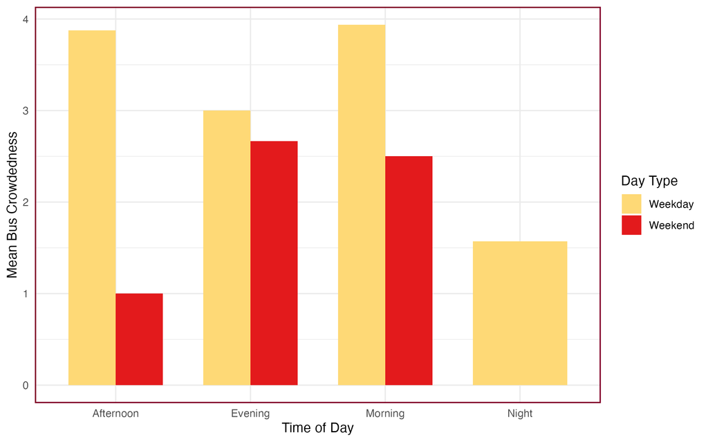

In the bar chart above we explore how crowdedness(on a scale of 1-5) varies across different parts of the day, separating weekdays from weekends.

The results are actually quite interesting, as we see similar and higher peaks from morning and afternoon (score ~4) time of day during the weekdays compared to the evenings. This might due to bias of the population as I(uni student) mostly finish uni either before the evening or at night and I’m presuming this might be similar to most students schedules, hence the most crowded period time of day are usually Mornings and Afternoons(potentially closer to 3pm as opposed to noon).

## Mastering Tetris on a Moving Bus

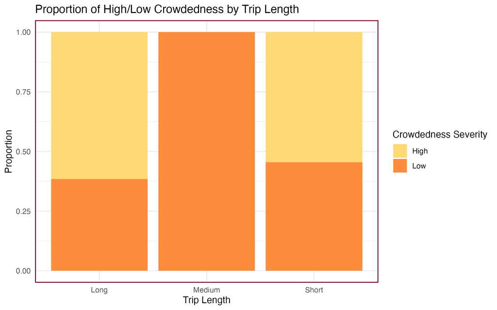

## Exposing Buses who are chronically late…

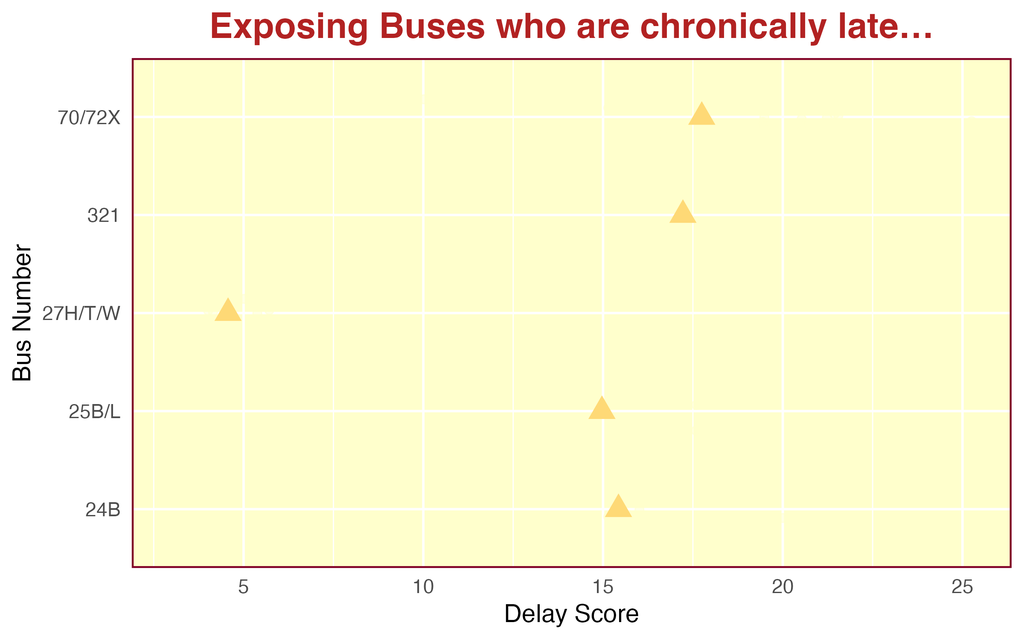

Finally for our last plot, we can expose some bus numbers. This plot compares delay scores (a metric combining duration, distance, and crowdedness) across different bus routes.

## Lets wrap this up

[figure not shown]

Homer Simpson

Through this journey, I discovered when buses are most reliable, how crowdedness fluctuates, and which routes tend to run late. By combining simple transformations with some custom metrics, I got a much better understanding of how my daily transport works. While the insights are specific to my experience and are introduced to some bias, the process shows how data logging and visualisation can reveal patterns that help us make better decisions. The main takeaway for today is **AVOID THE 70**(jokes).